# Multinational firms and tax havens: Python Assingment AEA1

```python
#Import Plotly
import plotly
plotly.tools.set_credentials_file(username='koenjereskes', api_key='72hsZSY2nMwjgEm8rw1x')
```

```python
import plotly.plotly as py
from plotly.tools import FigureFactory as FF

data_matrix = [['Student Name', 'ANR', 'Github'],
               ['Robbert van Riel', 571548, '<a href="https://github.com/RobbertvanRiel">RobbertvanRiel</a>'],
               ['Koen Jereskes', 883623, '<a href="https://github.com/koenjereskes">koenjereskes</a>'],
               ['Frank van Casteren', 540947, '<a href="https://github.com/FrankvanCasteren">FrankvanCasteren</a>']]

table = FF.create_table(data_matrix)
py.iplot(table, filename='simple_table')
```

[interactive chart not shown]

### 1. Abstract

Multinational firms with operations in high-tax countries can benefit the most from reallocating taxable income to tax havens. By using the theoretical framework by [Gumpert, Hines and Schnitzer, 2016](http://cepr.org/sites/default/files/news/CEPR_FreeDP_120916.pdf), we estimate the domestic tax rate for multinationals where they will not report any domestic profits under different profit shifting costs. We find that the lower the costs, the lower the domestic tax rate needs to be in order for a firm to shift all their profits to a possible foreign affiliate.

### 2. Introduction

Tax havens are typically small countries with high-quality governance institutions. They impose low or zero tax rates on foreign investors ([Dharmapala and Hines, 2009](http://www.nber.org/papers/w12802.pdf)). Sophisticated tax avoidance strategies involving tax havens have received considerable attention in the media ([The Independent, 2016](http://www.independent.co.uk/news/uk/politics/tax-havens-bermuda-worst-zero-per-cent-corporation-tax-rate-a7469386.html)). There are roughly 40 major tax havens in the world today, but the sizable apparent economic returns to becoming a tax haven raise the question of why there are not more. Both the OECD and a dataset by Rice and Hines identify which tax havens there are [Appendix Table 1 Dharmapala and Hines, 2009](http://www.nber.org/papers/w12802.pdf#page=34). Tax havens have been in the focus of national and international policy measures. Their interest is in the concern that tax havens are widely used to avoid tax obligations in their high-tax countries. The purpose of our investigation is to identify the factors that determines the demand for tax havens and the incentive of profit shifting. According to [Gumpert, Hines and Schnitzer, 2016](http://cepr.org/sites/default/files/news/CEPR_FreeDP_120916.pdf), who focus their investigation on German multinationals, state that a one percent increase in the foreign tax rate leads to a 2.3 per cent increase in having a tax haven affiliate, reflecting the greater benefit of reallocating taxable income from high-tax countries.

### 2.1. Research question

*How is profit shifting of multinationals related to domestic tax rates and costs of profit shifting, suggesting having a tax haven affilate?*

### 2.2. Motivation

Due to the economic integration, markets are interlinked and firms are more likely to be globally active, having subsidiaries located all over the world. One would expect a so-called *race to the bottom*, where due to government deregulation of the business environment or taxes economic activity is attracted in their jurisdictions. This turned out not to be true. In a paper by [Huizinga and Nicodème (2008)](http://www.sciencedirect.com/science/article/pii/S001429210500053X) this unexpected outcome is explained by the increasing foreign ownership, which led to the incentive to increase corporate tax levels as this introduces the possibility of tax exportation.

Our research question provide additional understanding and interpretation on the phenomena which is economic integration and its above mentioned effects and mechanisms.

### 3. Theoretical framework

In this section we create the theoretical framework behind the paper of [Gumpert, Hines and Schnitzer, 2016](http://cepr.org/sites/default/files/news/CEPR_FreeDP_120916.pdf). The theoretical framework is based on the incentive for a multinational firm to invest in a tax haven. A multinational firm can choose invest in a range of countries $i = 0,...,n.$ where country 0 is the taxhaven. Other variables are:

$c_i$ = Fixed set-up cost

$\rho_i$ = Before-tax profits earned in country $i$ by the affiliate once installed

$\tau_i$ = reported profits are taxed at this rate in country $i$

Assume $\tau_0$ = 0 i.e there is no taxation in tax haven.

$\psi_i$ = amount of actual profits in country $i$ that can be reallocated to a country with lower tax rate. Assume income reallocation gets increasingly expensive as the amount reallocated increases relative to income earned in country $i$.

$(\alpha/2)(\psi_i^2/\rho_i)$ are the assumed costs income reallocation according to <a href = "http://www.nber.org/papers/w3477.pdf" > Hines and Rice (1994)</a>.

Where $\alpha$ is a parameter that captures how much the cost of income reallocation increases with the amount reallocated. Note that $a$ is firm specific and we will elaborate on this in more detail in our discussion session. Now we assume that the cost of reallocation are incurred in the country from which income is shifted. Reported profit in country $i$, $\pi_i$, after fixed cost $c_i$ are sunk is thus \begin{eqnarray} \pi_i = \rho_i - \psi_i - \frac{\alpha}{2} \frac{\psi_i^2}{\rho_i} \end{eqnarray}

The investor's maximization problem, given that firm has a tax haven affiliate, is

\begin{equation} \max_{d_i,\psi_i}\sum_{i=1}^{n} d_i \Bigg[\psi_i + (1-\tau_i)(\rho_i - \psi_i - \frac{\alpha}{2} \frac{\psi_i^2}{\rho_i})-c_i\Bigg] \end{equation}

With $d_i$$\in$ {$0,1$}, s.t.

\begin{eqnarray} \rho_i - \psi_i - \frac{\alpha}{2} \frac{\psi_i^2}{\rho_i} \geq 0 \space \forall_i = 1,...,n. \end{eqnarray}

*LEMMA 1 : If the investor has a tax haven affiliate, the optimal amount of profit shifting is:*

\begin{eqnarray} \psi_i^{*th} = \frac{\tau_i\rho_i}{\alpha(1-\tau_i)} \end{eqnarray}

### 3.1. Importing libraries and packages

```python
import matplotlib.pyplot as plt
from IPython.display import display, Math, Latex
import numpy as np
%matplotlib inline
%precision 4
from __future__ import division
```

### 3.2. Execution

```python
tag= 0.315 # tax rate for German firm
tah = 0.15 # Tax rate for Hungarian firm
rho = 10000 # Before tax profits earned in country i we assume 10000
alpha = 0.4 # Cost of income reallocation
psig= (tag*rho)/(alpha*(1-tag)) # amount of profit shifting German firm
psih = (tah*rho)/(alpha*(1-tah)) # amount of profit shifting Hungarian firm
print psig
print psih
```

```
11496.350365
4411.76470588
```

```python
taug = (psig*alpha/rho)/(1+((psig*alpha)/rho)) #Domestic tax function for Germany
tauh = (psih*alpha/rho)/(1+((psih*alpha)/rho)) #Domestic tax function for Hungary
print taug
print tauh
```

```
0.315
0.15
```

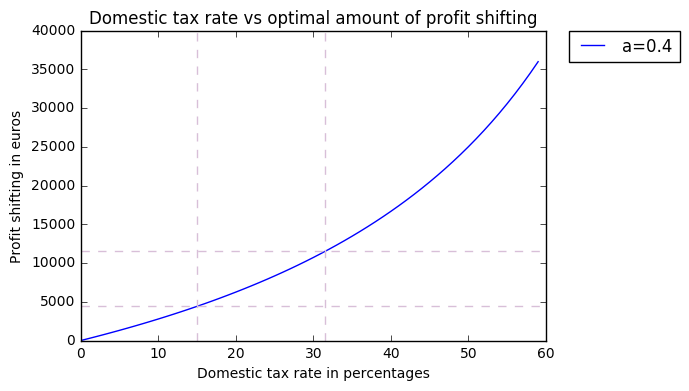

```python
taus = np.arange(0, 0.6, 0.01);
psis = (taus*rho)/(alpha*(1-taus))
plt.plot(taus*100, psis, "b", label="a=0.4")
plt.axvline(x=taug*100,color="thistle",linestyle="--") # German firm
plt.axhline(y=psig,color="thistle",linestyle="--") # German firm
plt.axvline(x=tauh*100,color="thistle",linestyle="--") # Hungarian firm
plt.axhline(y=psih,color="thistle",linestyle="--") # Hungarian firm
plt.title("Domestic tax rate vs optimal amount of profit shifting")
plt.legend(bbox_to_anchor=(1.05, 1), loc=2, borderaxespad=0.)
plt.xlabel ('Domestic tax rate in percentages')
plt.ylabel ('Profit shifting in euros')
```

The graph indicates the amount of profit each firm shifts to a foreign tax haven affilate. You'll find the corresponded values over here.

In this paper, the main focus is to determine the impact of tax rates on the incentive to set up a tax haven. Proposition 1 describes how a change in tax rates in countries in which the multinational is active independent of a tax haven investment, i.e $i=1,...,\hat{n},$ affects the incentive to set up a tax haven.

*Proposition 1: The larger the tax rate in countries in which the multinational is active independent of a tax haven investment, the larger is the incentive to establish a tax haven affiliate.*

\begin{eqnarray} \frac{dInc_{th}}{d\tau_i} = \frac{d(\Pi_i^{th}-\Pi_i^{nth})}{d\tau_i}= (\psi_i^{*th}-\psi_i^{*nth}) + \Bigg[\frac{a}{2}\frac{\psi_i^{*th2}}{\rho_i} - \frac{a}{2}\frac{\psi_i^{*nth2}}{\rho_i}\Bigg] > 0 \space \forall_i = 1,...,\hat{n}. \end{eqnarray}

We want to prove this proposition by using the following theoretical framework by [Gumpert, Hines and Schnitzer, 2016](http://cepr.org/sites/default/files/news/CEPR_FreeDP_120916.pdf):

\begin{eqnarray} (1-\tau_i)\pi_i = (1-\tau_i)(\rho_i - \psi_i - \frac{a}{2} \frac{\psi_i^2}{\rho_i}) = (1-\tau_i) \bigg[1- \frac{\tau_i(2-\tau_i)}{2\alpha(1-\tau_i)^2}\bigg] \rho_i \end{eqnarray}

Which can be rewritten to \begin{eqnarray} \pi_i = \bigg[1- \frac{\tau_i(2-\tau_i)}{2\alpha(1-\tau_i)^2}\bigg] \rho_i \end{eqnarray}

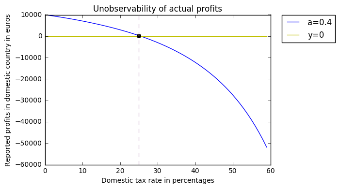

```python
rho = 10000 # Before tax profits earned in country i we assume 10000
alpha = 0.4 #baseline
taup = np.arange(0, 0.6, 0.01);

rp = (1-((taup*(2-taup))/(2*0.4*(1-taup)**2))) * rho # Formula where rp(reported profits) = πi
yline = np.arange(0, 0.6, 0.01) # In order to see the intersection with the y=0 where 0 profits are reported in the home country
plt.plot(taup*100,rp, "b",label="a=0.4")
plt.plot(taup*100, yline , "y",label="y=0")
idx = np.argwhere(np.diff(np.sign(rp-yline)) != 0).reshape(-1) + 0 # In order to place a point on the intersection between rp and yline
plt.plot(taup[idx]*100, rp[idx], 'ko')
plt.legend(bbox_to_anchor=(1.05, 1), loc=2, borderaxespad=0.)
plt.axvline(x=25,color="thistle",linestyle="--") # For clearing the x-value of intersection even more.
plt.title("Unobservability of actual profits")
plt.xlabel ('Domestic tax rate in percentages')
plt.ylabel ('Reported profits in domestic country in euros')
```

```python
print int(idx) # tax rate where a firm does not report any profits in home country.
```

```
25
```